# Going to France: The big day

the trip to Nancy

going to France

Nancy

Published

October 4, 2021

> A very intense day. (23rd to 24th of August of 2021)

# Before the airport

The night before the trip I managed to get my luggage in the acceptable weigth range and tried to sleep as much as possible.

On the day of the trip, I spent my morning giving my last farewells, had lunch at a good restaurant with my family, and tried to keep composture below all the stress of the uncertainty.

Luckily I had been doing lots of exercise the days before the trip, otherwise it would have been even more stressful.

[figure not shown]

# At the airport

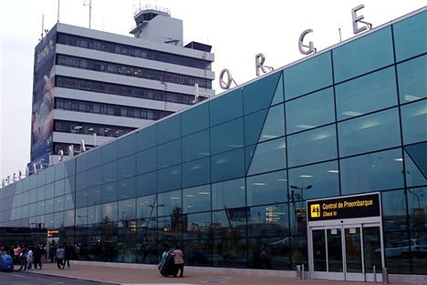

Some weeks before my trip, a friend who was also going to France added me to a Whatsapp group of Peruvian students leaving for France in the same semester.

Because of the small amount of flights due to COVID restrictions, it happened that some students were also going in the same flight as me. We decided to meet up at the airport. *This was a very wise decision*.

I arrived three hours before departure with all the [necessary documents](https://luisavasquez.github.io/quiescens-lct/posts/2021-09-29-wrapping-up.html), and due to COVID restrictions, only passengers were allowed into the airport, so I had to say farewell to my family outside.

Luckily, I could meet up with two students in the check-in line. After that, we had a snack, went through security and got to the plane gate, where we met two more students.

# In the plane

The plane was full of people moving to France (because Tourism trips were forbidden), and you could feel it in the atmosphere: most people had expressions of wearyness.

Anyway, the trip lasted **15 hours**.

In my experience, window seats are the best for sleeping lol.

# At the airport in Paris

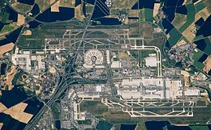

> The Charles de Gaulle Airport in Paris is **HUGE**

Getting around the airport takes a lot of time.

After getting out of the plane we had to walk for thirty minutes minutes to get to migration. There the line took almost one hour. None of us had any issue going through migration, but some had long delays at the luggage reclaim. My luggage took thirty more minutes to arrive, because of the amount of passengers in my flight.

Since some of the students had to take trains or buses soon, the group split.

After everyone in my group had their luggage, we headed to the train station inside the airport.

## Getting a phone number at the airport

I am going to be clear: the price of SIM cards at the CDG airport is a rip-off.

Nevertheless, I discovered that getting a SIM card this early helped me doing some bureaucracy later.

I payed **40 €** for a SIM card at a *Relay* shop at the CDG airport. It was a “plug and play” SIM card: just after inserting it I had internet data (20 GB). This was very useful for the rest of the trip for using Goolge Maps.

[figure not shown]

## Getting to the train station at the airport

One has to walk a lot to get to the train station at the CDF airport.

With two big luggages each, it took our group almost an hour to get to the train station after passing migration.

There our group dispersed, and only I and another student were getting on the same train (not getting off in the same city, though).

> It took **4 hours** since I got off the plane until I got on the train

I told you, Charles de Gaulle Airport is huge!

PD: If you see a bathroom, use it! You won’t find another one in a long time (1€ coin or credit card to enter the bathroom).

[figure not shown]

# In the Train

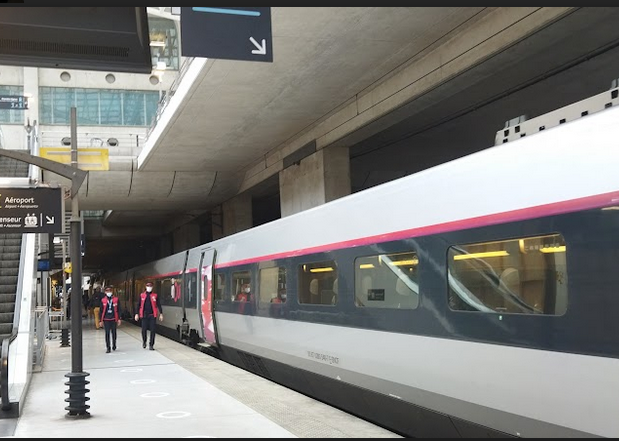

The way to get to the TGV is by looking for the gate at the CDG airport.

It came around 20 minutes before departure, and it got full *fast*.

I had reserved a seat, but the train was so big it took me time to find it. Before that I had to look for space two train cars to the side.

The trip was during the afternoon, and we quickly got to the French countryside.

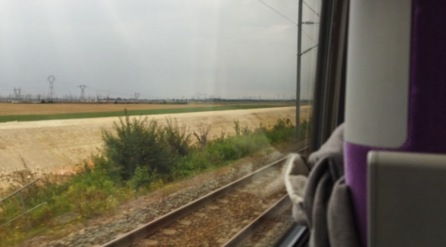

# In the bus to Nancy

Finally the train got to the Lorraine TGV station, where I had 20 minutes to transfer to the bus to Nancy.

Luckily it was easy to find. There was a huge parking lot outside the station, but only two buses where there, one to Nancy and another to Metz.

[figure not shown]

It was here where I had my first culture shock.

I had my QR code for my bus ticket reservation, but the bus driver couldn’t scan it. Then he just said he believed me, and allowed me to get in the bus.

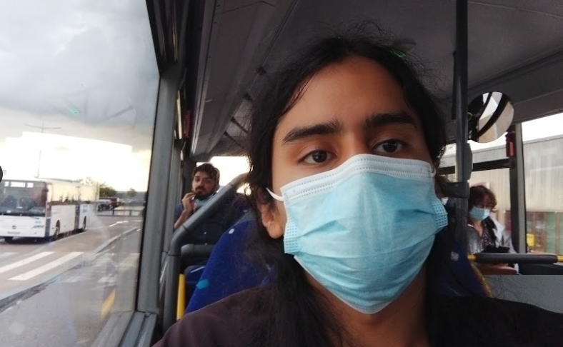

# In Nancy

Several weeks before arriving in Nancy, I got in contact with a student of the Master at the Université de Lorraine.

My bus was going to arrive when the reception of the student residence had already closed, so I was looking for a place to sleep until the next day.

This friend (lets call them $A$) was not in Nancy, but hey left me their keys with one of their friends (lets call them $B$).

Coming back to the day of my trip to France, I arrived to Nancy around 5 pm.

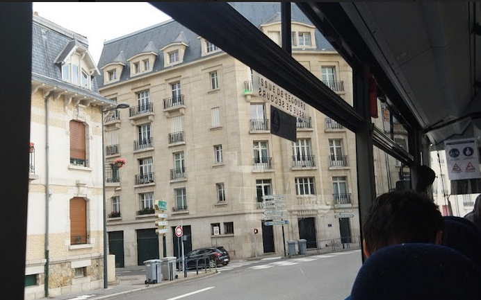

So, $B$ picked me up at the bus stop and took me to $A$’s room. $B$ started telling me about the city and the IDMC.

As it so happened, it started to rain just after steping off the bus, and it stopped when we were really close to $A$’s room. My luck!

We ordered dinner on an app, and after talking for a while, $B$ had to go. As a small tour, I accompanied $B$ to their house and we managed to pass by different landmarks in Nancy and by the IDMC.

Luckily, since I had mobile data from the SIM I bought at the airport, I could use Google Maps to get back.

After getting back, I made calls to friends and family and went to sleep.

The next day I had to get to the Batelière Residence at 10 am to pick up my keys.

> Finally, after all that bureaucracy, I had arrived to Nancy to study

# My advise

These made the trip easier to bear:

- Meet up with other people doing the same trip

  Why do I say it was a wise decision? Because having someone around that is going through the same stressful process helped us share the burden.

  Even though we didn’t keep contact, we helped each other during the trip (navigating around, speaking French, etc.)
- Buy a phone number at the French airport

  Having a French phone number so early helped me get some bureaucracy done quicker
- Have someone pick you up when you arrive

  At the end of the tedious trip, it is easier to get guidance from someone that already knows the place